# Portfolio 3

Martine Lind Jensen

12/11/2019

```r
library(pacman)

pacman::p_load(tidyverse, pastecs, WRS2, stringi, stringr, anytime)
```

```r
#get a vector with names of files using list.files()
files <- list.files(path = "data",
                    pattern = ".csv",  #everything that contains '.csv' in its name will be listed
                    full.names = T)    #makes it include directory path, so instead of 'logfile_1.csv' it will be 'data/logfile_1.csv')

#read all the files into a tibble
data <- lapply(files, read_csv) %>%
  plyr::rbind.fill()

#Changing to numeric
data$Response_Time <- as.numeric(data$Response_Time)

#Removing na
data <- na.omit(data)

#Removing wrong words
data <- filter(data, Word != "ago,the")
```

*Part 1: Correlation analysis of word length, word frequency and word number*

Which properties of words correlate with word-by-word reading times?

**Testing assumptions for response time data.**

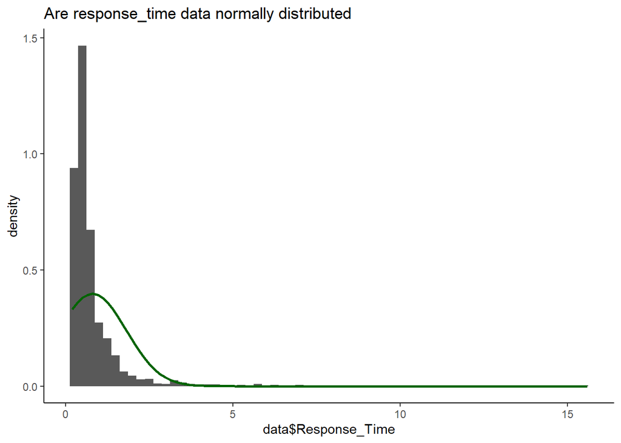

```r
#Checking if response_time data is normally distributed
#Histogram response_time data
ggplot(data, aes(x = data$Response_Time)) +
  geom_histogram(aes(y = ..density..), binwidth = 0.25) +
  ggtitle("Are response_time data normally distributed") +
  stat_function(fun = dnorm, args = list(mean = mean(data$Response_Time, na.rm = TRUE), sd = sd(data$Response_Time, na.rm = TRUE)), colour= "darkgreen", size = 1)+
  theme_classic()
```

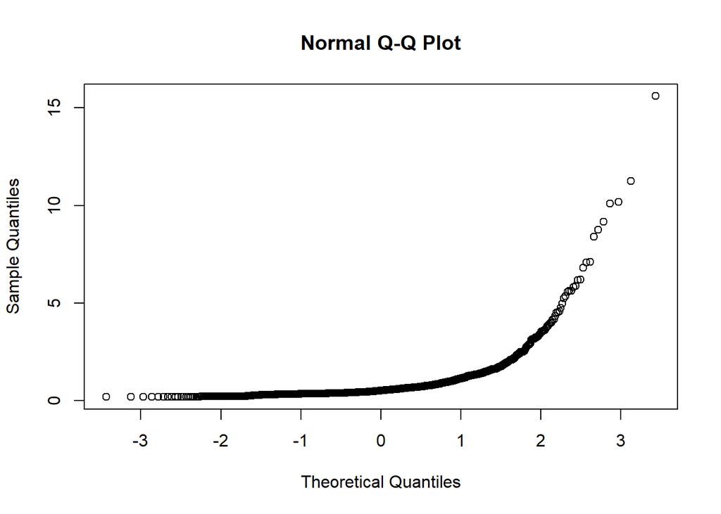

```r
#qqplot response_time data
qqnorm(data$Response_Time)
```

```r
#Descriptive stats response_time data
round(pastecs::stat.desc(data$Response_Time, basic = FALSE, norm = TRUE), digits = 2)
```

```
##       median         mean      SE.mean CI.mean.0.95          var
##         0.52         0.81         0.02         0.05         1.00
##      std.dev     coef.var     skewness     skew.2SE     kurtosis
##         1.00         1.24         6.18        51.56        56.53
##     kurt.2SE   normtest.W   normtest.p
##       236.08         0.47         0.00
```

The data are not normally distributed, therefore i’ve tried to transform the data and remove the outliers. Then i’ve checked for normality.

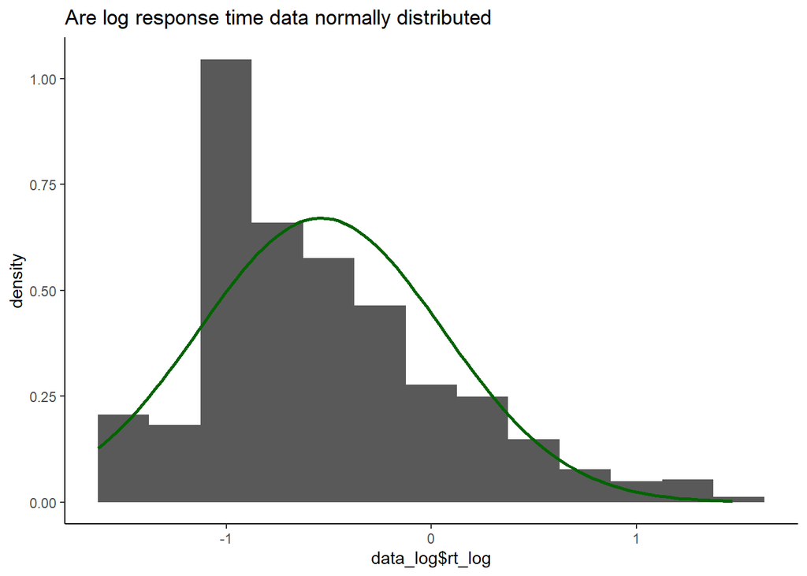

```r
#The data are not normally distributed
data_log <- data %>% mutate(rt_log = log(data$Response_Time)) #log transformation

#Removing outliers
data_log$z <- (data_log$rt_log-mean(data_log$rt_log))/sd(data_log$rt_log)

data_log <- filter(data_log, z < 3 & z > -3)

#Checking if rt_log data is normally distributed
#Histogram response_time data
ggplot(data_log, aes(x = data_log$rt_log)) +
  geom_histogram(aes(y = ..density..), binwidth = 0.25) +
  ggtitle("Are log response time data normally distributed") +
  stat_function(fun = dnorm, args = list(mean = mean(data_log$rt_log, na.rm = TRUE), sd = sd(data_log$rt_log, na.rm = TRUE)), colour= "darkgreen", size = 1)+
  theme_classic()
```

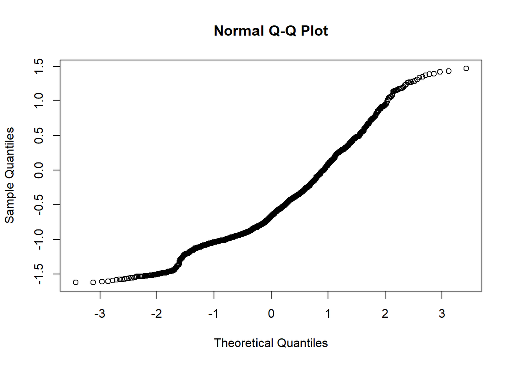

```r
#qqplot rt_log data
qqnorm(data_log$rt_log)
```

```r
#Descriptive stats response_time data
round(pastecs::stat.desc(data_log$rt_log, basic = FALSE, norm = TRUE), digits = 2)
```

```
##       median         mean      SE.mean CI.mean.0.95          var
##        -0.66        -0.54         0.01         0.03         0.35
##      std.dev     coef.var     skewness     skew.2SE     kurtosis
##         0.59        -1.10         0.85         7.02         0.47
##     kurt.2SE   normtest.W   normtest.p
##         1.96         0.95         0.00
```

The histogram, qqplot and all of the statistical tests doesn’t approach normality. The p-value (p = .00) is very low, and the kurtosis (kurt.2SE > 1) and the skewness (skew.2SE > 1) are both bigger than one, which is very poor numbers for normally distributed data.

We use response time in all of the correlation, and since that is not normally distributed, i have decided to use kendalls tau as a correlation test. Kendalls tau doesn’t assume normality and probably works better with smaller data sets, and we work with a data set with 20 participants, which is small data set.

**Testing correlation between word length and response time.**

Checking correlation between word length and response time.

The hypothesis is that the longer the word is, the longer time it takes to read it.

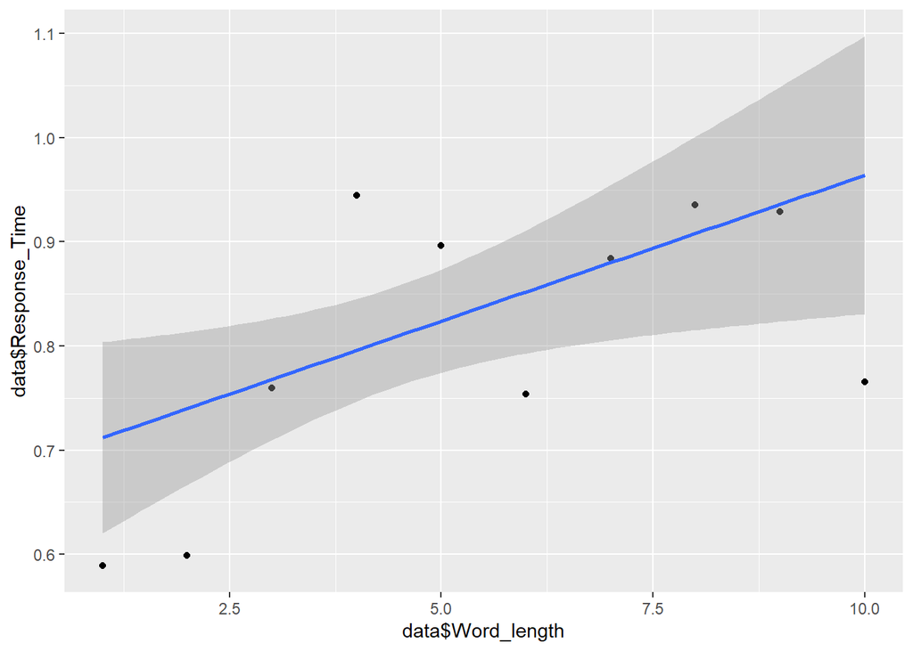

```r
#Making a new coloumn with word length

#Removing all else than letters
data$Word <- str_replace_all(data$Word, "[:punct:]","")

#Counting letters in the word
data$Word_length <- nchar(data$Word)

ggplot(data, aes(x = data$Word_length, y = data$Response_Time)) +
  geom_point(stat = "summary", fun.y = mean) +
  geom_smooth(method = "lm")
```

```r
#Cant get spearman to work
cor.test(data$Word_length, data$Response_Time, method = "kendall")
```

```
##
##  Kendall's rank correlation tau
##
## data:  data$Word_length and data$Response_Time
## z = 3.7343, p-value = 0.0001882
## alternative hypothesis: true tau is not equal to 0
## sample estimates:
##        tau
## 0.06519869
```

There is a very small increase in response time as the word becomes longer tau = .06 and p < 0.01.

The correlation coeffecient (tau) is less than .1 which means that the effect size is almost non existing. But the p-value is less than .01, which means that the effect size is statistically significant.

**Testing correlation between word frequency and response time.**

Checking correlation between word frequency and response time.

The hypothesis is that the more frequent a word is, the less time it takes to read.

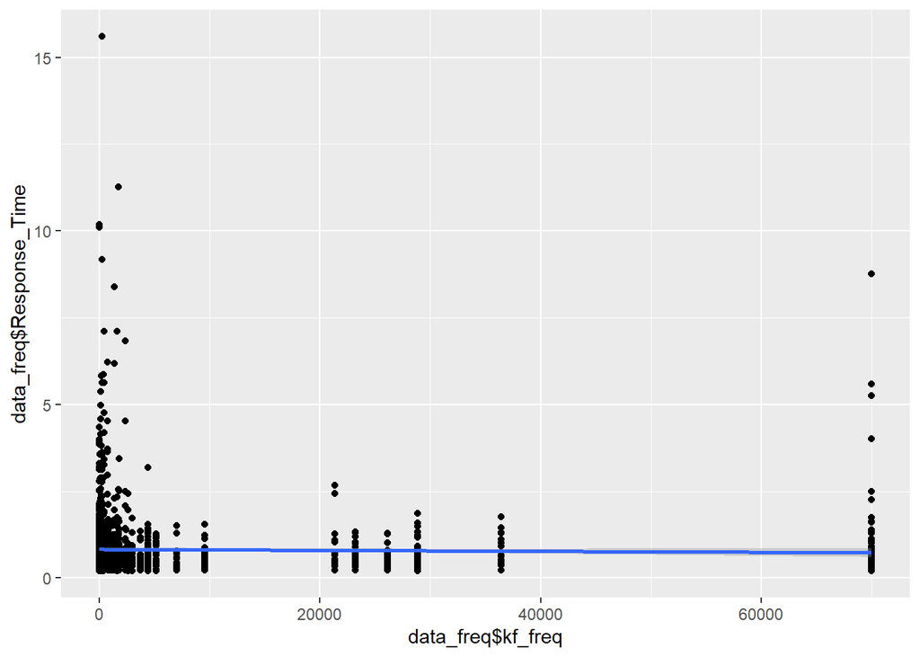

```r
MRC <- read.csv("MRC_database.csv")

logfile <- data

#Rename the capitalized column to "word"
colnames(logfile)[colnames(logfile)=="Word"] <- "word"

#Convert your words into uppercase
logfile$word <- toupper(logfile$word)

#Mergin the two dataframes
data_freq <- merge(MRC, logfile, by = "word")

#Plotting the data
ggplot(data_freq, aes(x = data_freq$kf_freq, y = data_freq$Response_Time)) +
  geom_point() +
  geom_smooth(method = "lm")
```

```r
cor.test(data_freq$kf_freq, data_freq$Response_Time, method = "kendall")
```

```
##
##  Kendall's rank correlation tau
##
## data:  data_freq$kf_freq and data_freq$Response_Time
## z = -3.1571, p-value = 0.001594
## alternative hypothesis: true tau is not equal to 0
## sample estimates:
##         tau
## -0.05190694
```

**Testing correlation between word number and response time.**

Checking correlation between the order of the word and the response time.

The hypothesis is that people get faster at reading, the further in the experiment they get.

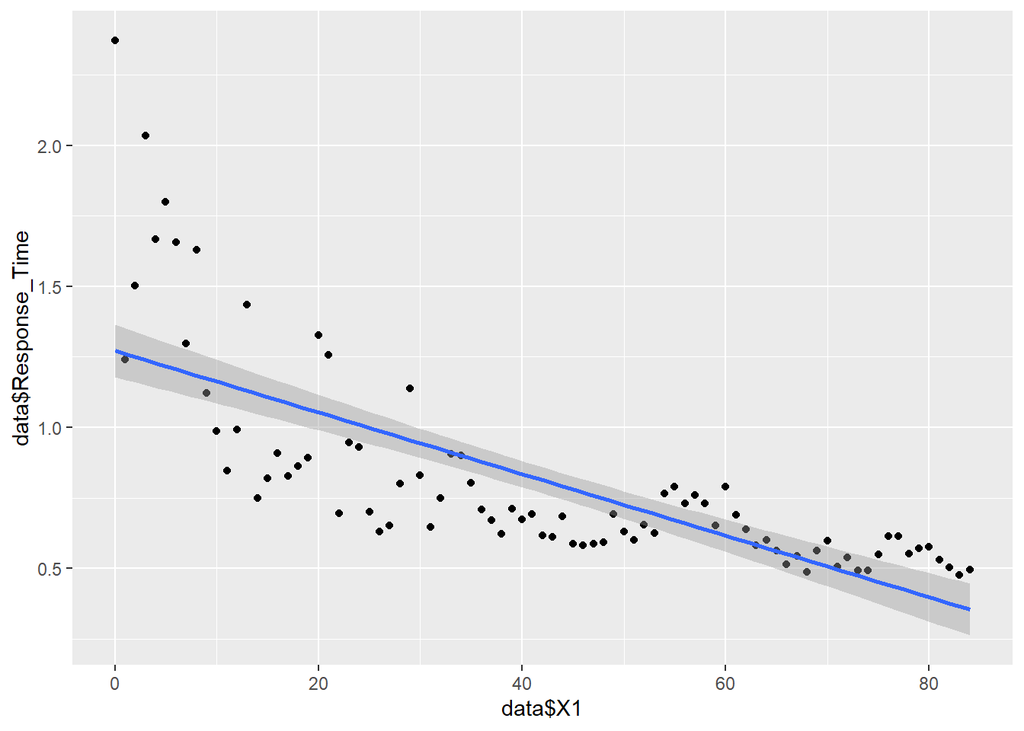

```r
#Plotting the data
ggplot(data, aes(x = data$X1, y = data$Response_Time)) +
  geom_point(stat = "summary", fun.y = mean) +
  geom_smooth(method = "lm")
```

```r
cor.test(data$X1, data$Response_Time, method = "kendall")
```

```
##
##  Kendall's rank correlation tau
##
## data:  data$X1 and data$Response_Time
## z = -9.123, p-value < 2.2e-16
## alternative hypothesis: true tau is not equal to 0
## sample estimates:
##        tau
## -0.1498596
```

There is a small decrease in response time as the word number increases tau = .15, p < 0.01.

The correlation coeffecient (tau) is bigger than .1 which is a small effect, and the p-value is less than .01, which means that the effect size is statistically significant.

**Conclusion part 1**

The word length showed a very small effect, but our text did not include any high-level reading words, so maybe the effect would have been bigger, if the text included longer and harder words.

*Part 2: Comparing means of the surprise word and the follow-up word across condition with t-test*

How do semantic-contextual expectations affect reading times?

Our hypothesis is that it takes longer time to read a semantically different word than a normal word.

**Filtering data**

Filtering the data so i have two seperate dataframes containing the suprise/normal word (“kiss”/“save”) and the follow-up word (“the”)

```r
data_clean <- filter(data, X1>=81)

data_clean <- filter(data_clean, X1<=83)

data_clean <- filter(data_clean, Word != "can")

data_clean <- filter(data_clean, Word != "world")

the_df <- filter(data_clean, Word == "the")

ks_df <- filter(data_clean, Word != "the")
```

**Testing assumptions, transforming data and removing outliers**

Testing assumption of normality to find out which t-test to use.

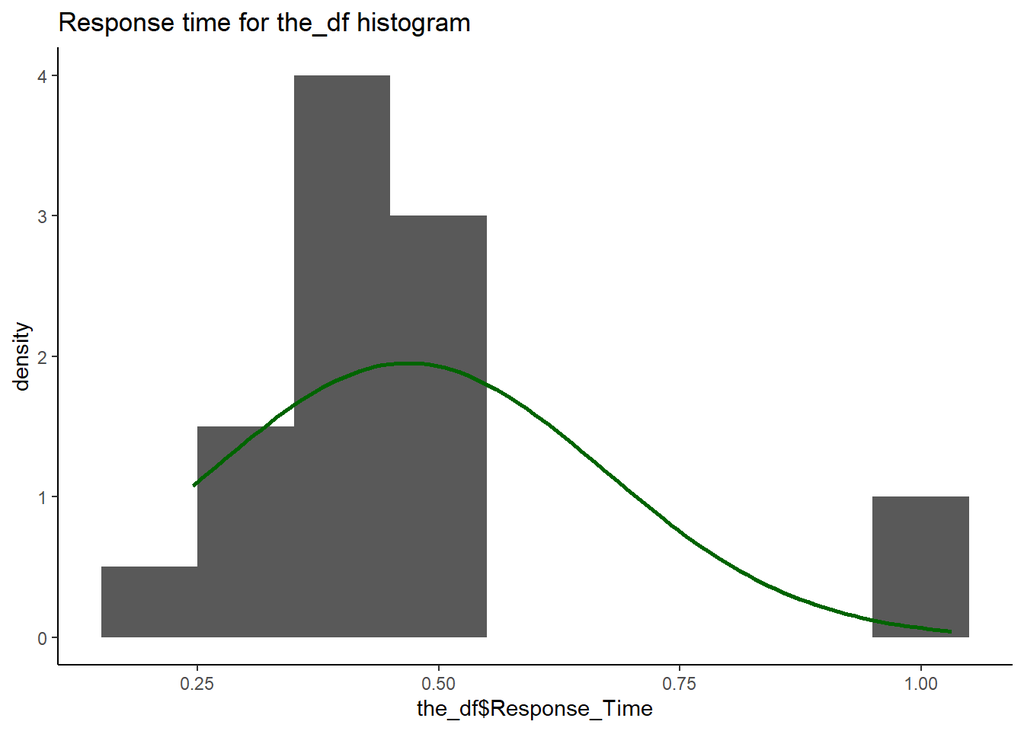

```r
#The data
#Histogram "the" data
ggplot(the_df, aes(x = the_df$Response_Time)) +
  geom_histogram(aes(y = ..density..), binwidth = 0.1) +
  ggtitle("Response time for the_df histogram") +
  stat_function(fun = dnorm, args = list(mean = mean(the_df$Response_Time, na.rm = TRUE), sd = sd(the_df$Response_Time, na.rm = TRUE)), colour= "darkgreen", size = 1)+
  theme_classic()
```

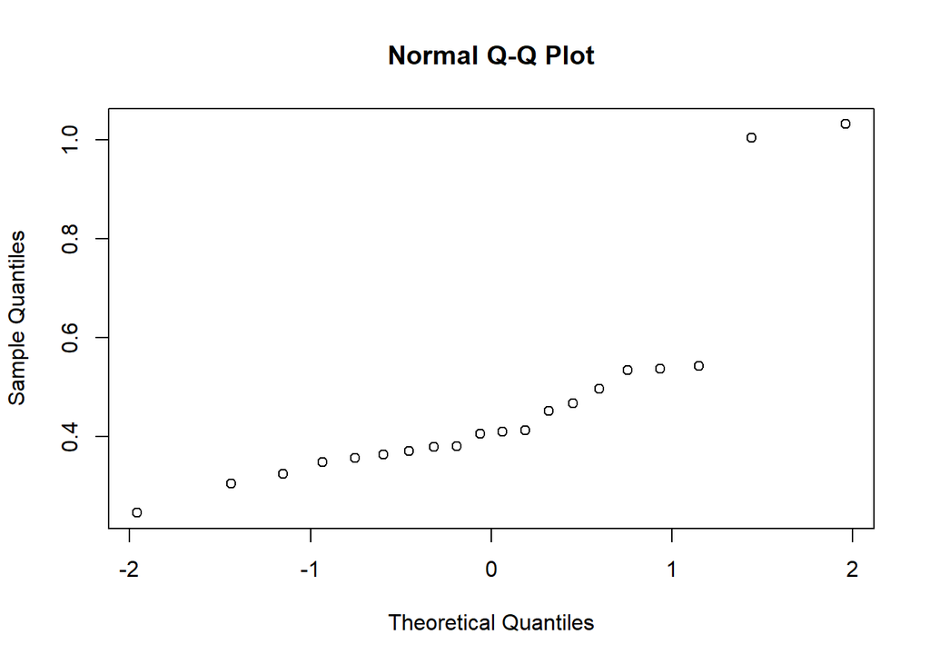

```r
#qqplot "the" data
qqnorm(the_df$Response_Time)
```

```r
#Descriptive stats "the" data
round(pastecs::stat.desc(the_df$Response_Time, basic = FALSE, norm = TRUE), digits = 2)
```

```
##       median         mean      SE.mean CI.mean.0.95          var
##         0.41         0.47         0.05         0.10         0.04
##      std.dev     coef.var     skewness     skew.2SE     kurtosis
##         0.20         0.44         1.81         1.77         2.41
##     kurt.2SE   normtest.W   normtest.p
##         1.21         0.72         0.00
```

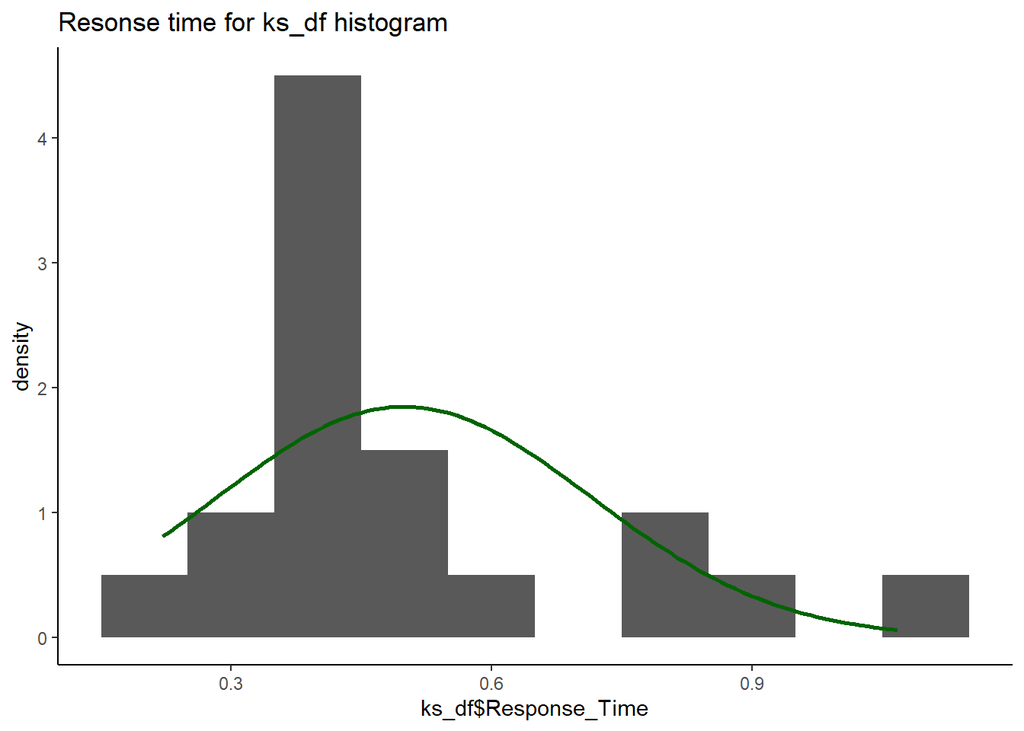

```r
#ks data
#Visual ks data
ggplot(ks_df, aes(x = ks_df$Response_Time)) +
  geom_histogram(aes(y = ..density..), binwidth = 0.1) +
  ggtitle("Resonse time for ks_df histogram") +
  stat_function(fun = dnorm, args = list(mean = mean(ks_df$Response_Time, na.rm = TRUE), sd = sd(ks_df$Response_Time, na.rm = TRUE)), colour= "darkgreen", size = 1)+
  theme_classic()
```

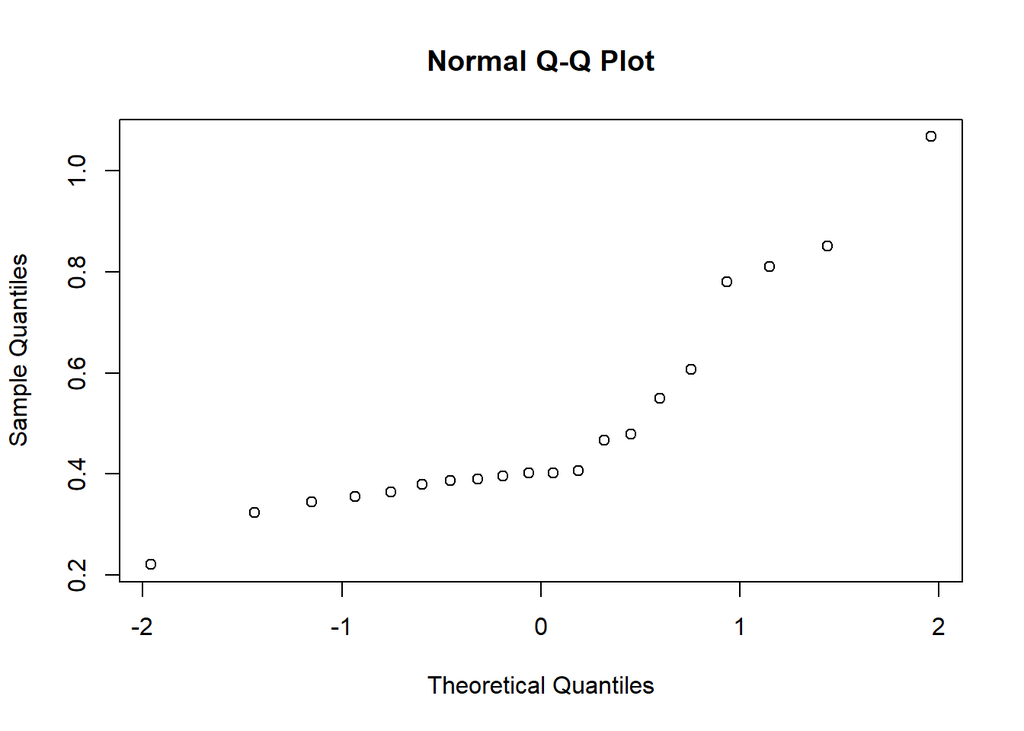

```r
qqnorm(ks_df$Response_Time)
```

```r
round(pastecs::stat.desc(ks_df$Response_Time, basic = FALSE, norm = TRUE), digits = 2)
```

```
##       median         mean      SE.mean CI.mean.0.95          var
##         0.40         0.50         0.05         0.10         0.05
##      std.dev     coef.var     skewness     skew.2SE     kurtosis
##         0.22         0.43         1.17         1.15         0.32
##     kurt.2SE   normtest.W   normtest.p
##         0.16         0.83         0.00
```

The data is not normally distributed and i estimate that it wont be normal even if i transform and removing outliers.

**Making plots comparing the means**

Barplot of the follow-up word with standard error as errorbars.

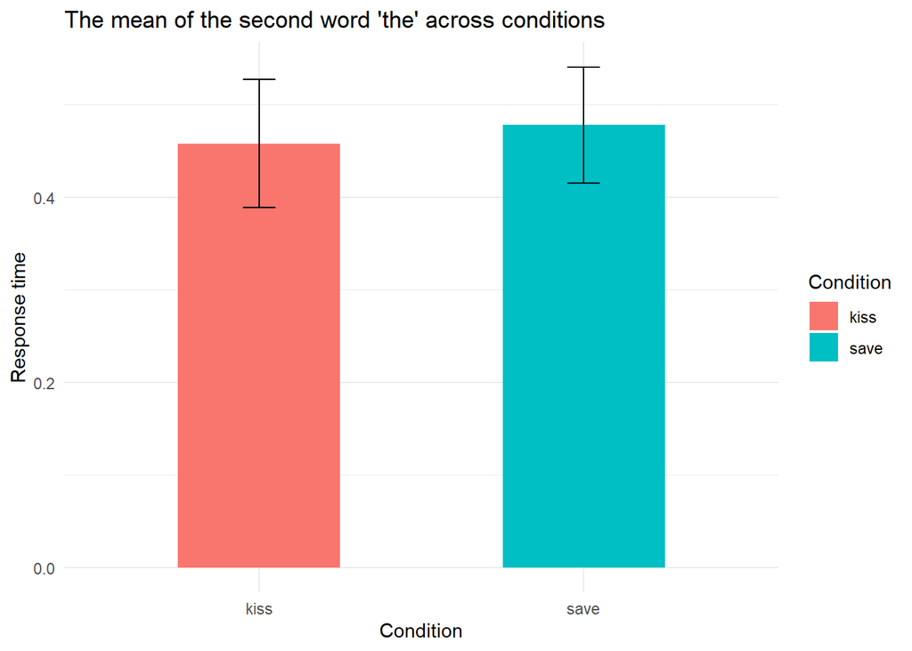

```r
#Follow up word "the"
ggplot(the_df, aes(x = the_df$Condition, y = the_df$Response_Time)) +
  theme_minimal() +
    labs(x = "Condition", y = "Response time") +
  geom_bar(aes(fill= Condition), stat='summary', fun.y = mean, width = 0.5) +
  stat_summary(fun.data = mean_se, geom = "errorbar", color = 'black', width = 0.1) +
  ggtitle("The mean of the second word 'the' across conditions")
```

The plot shows no difference of the mean of the follow-up word across conditions.

Barplot of the main word with standard error as errorbars.

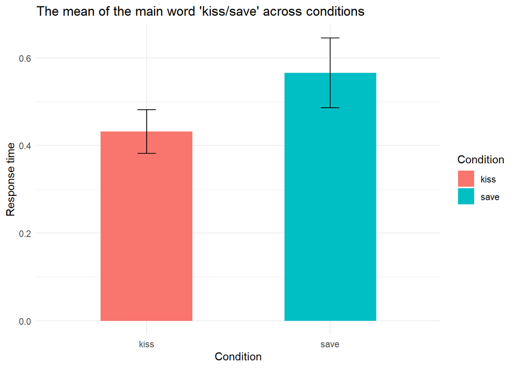

```r
#Main word kiss/save
ggplot(the_df, aes(x = ks_df$Condition, y = ks_df$Response_Time)) +
  theme_minimal() +
    labs(x = "Condition", y = "Response time") +
  geom_bar(aes(fill= Condition), stat='summary', fun.y = mean, width = 0.5) +
  stat_summary(fun.data = mean_se, geom = "errorbar", color = 'black', width = 0.1) +
  ggtitle("The mean of the main word 'kiss/save' across conditions")
```

The barplot seem to show some difference of the main-word across the condition. But unfortunately for our hypothesis it seems to be taking longer to read the normal word than the surprising word.

**T-test**

Making t-test to test the statiscally significance of compairing the means. I use the independent t-test from WRS2-package as the assumption of normality is violated and we have a between-participant design.

```r
#the_df
WRS2::yuen(Response_Time ~ Condition, data = the_df)
```

```
## Call:
## WRS2::yuen(formula = Response_Time ~ Condition, data = the_df)
##
## Test statistic: 0.3084 (df = 9.8), p-value = 0.7642
##
## Trimmed mean difference:  -0.01687
## 95 percent confidence interval:
## -0.139     0.1053
##
## Explanatory measure of effect size: 0.1
```

```r
#ks_df
WRS2::yuen(Response_Time ~ Condition, data = ks_df)
```

```
## Call:
## WRS2::yuen(formula = Response_Time ~ Condition, data = ks_df)
##
## Test statistic: 1.109 (df = 5.61), p-value = 0.31268
##
## Trimmed mean difference:  -0.11144
## 95 percent confidence interval:
## -0.3615     0.1386
##
## Explanatory measure of effect size: 0.5
```

In compairing the means of the follow-up word across condition, I have found no difference of the means *t*(9.8) = 0.3, p > .05.

In compairing the means of the main word across condition, I have found no statistical significance of difference between the means *t*(5.6) = 1.1, p > .05.

**Conclusion part 2**

I have found no statistically signifance in the reading time of a semantically different word in our experiment. This could be because, the suprise-word appear so late in the text, and as we saw in the correlation test of word number, there is a decrease of response time as the word number increases. I also have a small dataset, which could have an impact on the results.